# Insights on Ford GoBike System Data

## by Oluwanifemi Favour Olajuyigbe

## Investigation Overview

- What time/period most trips are taken?
- What factors affected the duration of the trip?

## Dataset Overview

The original data consisted of information about approximately 180,000 individual rides with 16 features. However, after being properly cleaned, the data contained 174,391 ride information and 11 attributes. The features included the five main areas of focus, duration_min, start_weekday, start_period, start_hour, user_type, as well as additional attributes such as start_day, member_birth_year, member_gender, age, duration_sec and start_station_name. 9,021 data points were removed from the original analysis due to inconsistencies or missing information.

## What time/period were most trips taken?

### Distribution of Days of the Week

Most trips were taken generally during weekdays, but more specifically on Thursdays as it had the highest number of trips started. Then, weekends (Saturdays and Sundays) had the lowest turn up rate.

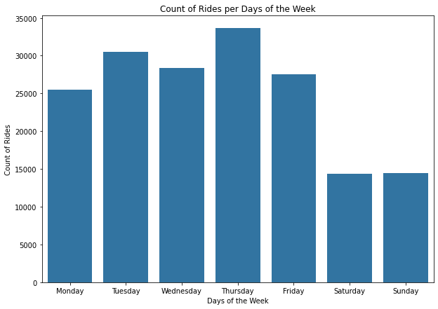

### Distribution of Start Period

People mostly took rides in the evenings, and then the mornings which had the second highest count of rides. Only a handful of people took rides in the late nights.

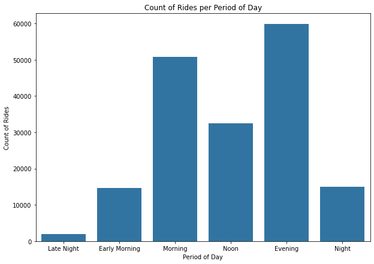

### Distribution of Hour the Trips Started

Most trips started at 8am and 5pm, then the least trips were taken at 3am. Here we see more specifically that more than 20,000 people have bike trips during the hours of 5pm and 8am, while between 1 and 4am not up to a thousand people go on a bike trip. Then an average of 7500 people had bike trips from 10am to 3pm.

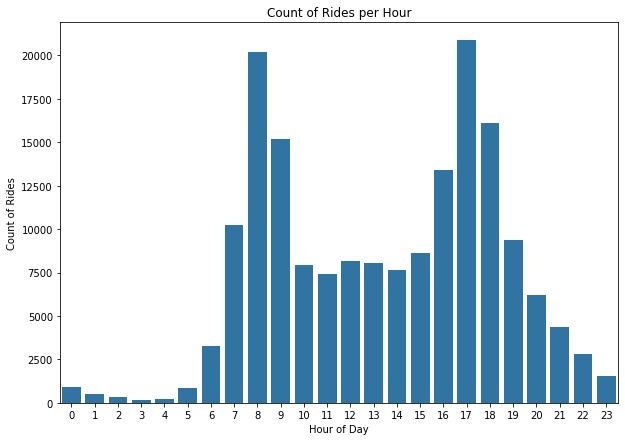

## Distribution of Duration in Minutes

The duration in minutes took on a large range of values and was highly skewed to the right. After performing a log transformation on the variable, the distribution of the duration took on a unimodal shape, with its peak between 5 and 20 minutes.

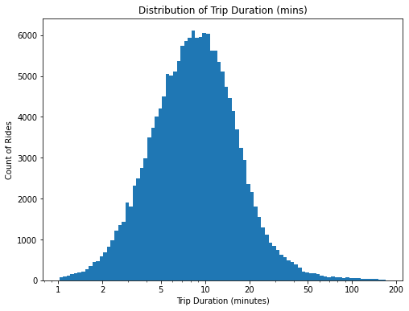

## What Factors had an Effect on the Duration of Trip?

### Duration (min) vs. Week Day

Plotting duration on a logarithmic scale, it can be seen that individuals had longer trips during the weekends, that is, Saturday and Sunday, than weekdays (Monday to Friday)

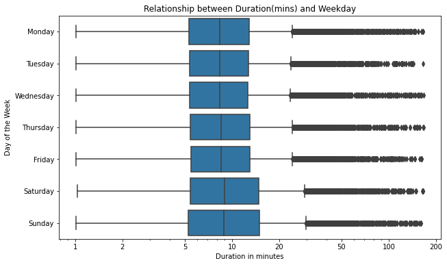

### Duration (min) vs. User Type

Plotting duration on a logarithmic scale, it can be seen that customers had a longer trip than subscribers.

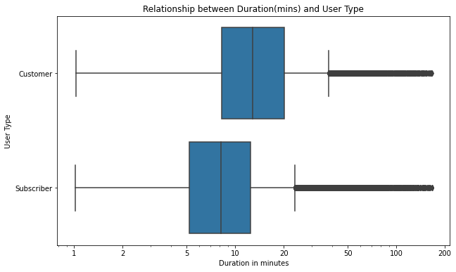

### Duration (min) by User Type and Week Day

Customers generally have a longer ride than subscribers regardless of the day of the week

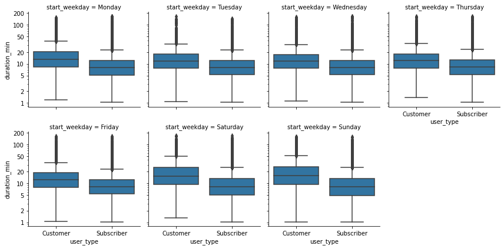